# describe_wings

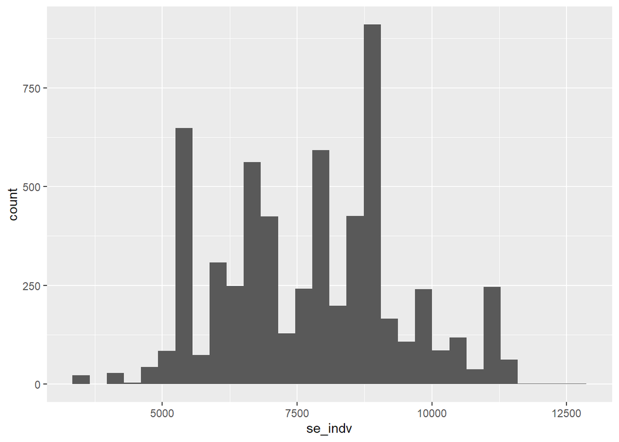

```
## [1] ""
## [1] "Length..inner..FW..mm."
##    Min. 1st Qu.  Median    Mean 3rd Qu.    Max.    NA's
##   10.01   25.84   31.43   31.87   38.71   60.74     136
```

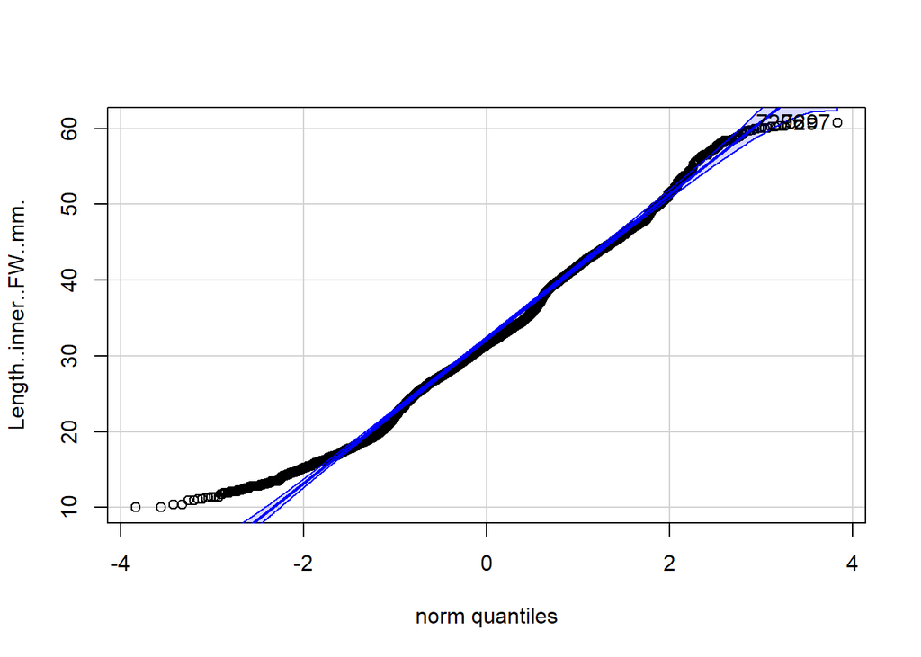

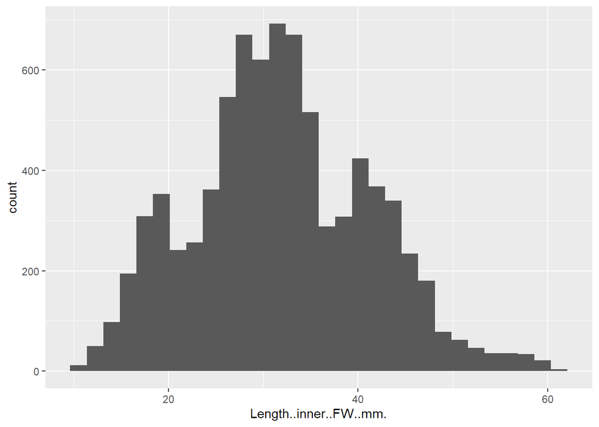

```
## [1] ""
```

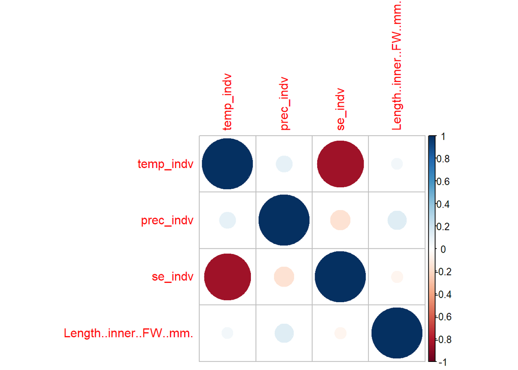

Climatic predictors fairly normally distributed

Temperature is strongly negatively correlated with seasonality

## Q3: How are predictors and responses associated?

```
##                                     x                      y         assoc
## ...1                            black                  black  1.000000e+00
## ...2                            brown                  black  2.456958e-01
## ...3                           yellow                  black  2.679073e-01
## ...4                      PC1_foreall                  black  9.781599e-02
## ...5                      PC2_foreall                  black  6.032814e-02
## ...6                      PC1_hindall                  black  8.686700e-02
## ...7                      PC2_hindall                  black  5.359436e-02
## ...8                              Sex                  black  9.813061e-02
## ...9                      flight_type                  black  1.132907e-01
## ...10                         species                  black  7.882469e-01
## ...11                          Family                  black  4.944653e-01
## ...12                         Country                  black  2.084900e-01
## ...13                       wing_type                  black  4.595030e-02
## ...14                       temp_indv                  black -1.352676e-01
## ...15                       prec_indv                  black -8.941166e-03
## ...16                         se_indv                  black  1.836181e-01
## ...17          Length..inner..FW..mm.                  black  1.233963e-01
## ...18                           black                  brown  2.456958e-01
## ...19                           brown                  brown  1.000000e+00
## ...20                          yellow                  brown  4.126167e-01
## ...21                     PC1_foreall                  brown  1.740183e-01
## ...22                     PC2_foreall                  brown  2.197111e-01
## ...23                     PC1_hindall                  brown  1.032602e-01
## ...24                     PC2_hindall                  brown  1.782781e-01
## ...25                             Sex                  brown  6.907052e-02
## ...26                     flight_type                  brown  1.007512e-01
## ...27                         species                  brown  6.529705e-01
## ...28                          Family                  brown  4.290382e-01
## ...29                         Country                  brown  2.162866e-01
## ...30                       wing_type                  brown  3.327154e-02
## ...31                       temp_indv                  brown  3.625855e-02
## ...32                       prec_indv                  brown  1.407857e-01
## ...33                         se_indv                  brown  1.517413e-02
## ...34          Length..inner..FW..mm.                  brown  3.504314e-01
## ...35                           black                 yellow  2.679073e-01
## ...36                           brown                 yellow  4.126167e-01
## ...37                          yellow                 yellow  1.000000e+00
## ...38                     PC1_foreall                 yellow  2.583743e-01
## ...39                     PC2_foreall                 yellow  2.242768e-01
```

[output cut: 525 more lines]

```
## ...275         correlation               8049         0.98338424
## ...276         correlation                915         0.11178986
## ...277         correlation                915         0.11178986
## ...278         correlation                915         0.11178986
## ...279         correlation                915         0.11178986
## ...280               anova               8049         0.98338424
## ...281               anova               7573         0.92522908
## ...282               anova               8049         0.98338424
## ...283               anova               8049         0.98338424
## ...284               anova               8049         0.98338424
## ...285               anova               8046         0.98301772
## ...286         correlation               5891         0.71973122
## ...287         correlation               5891         0.71973122
## ...288         correlation               5891         0.71973122
## ...289         correlation               8049         0.98338424
```

## Q4: What exactly are the colors that come out of optimized clustering?

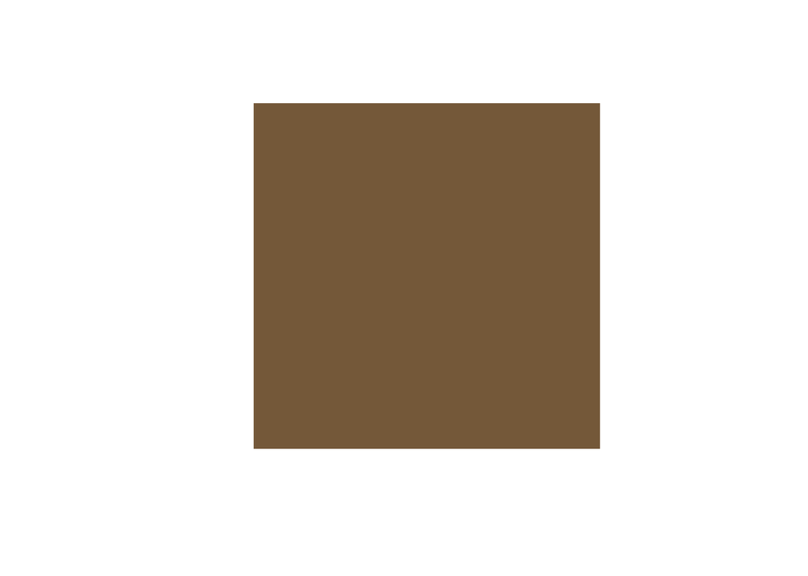

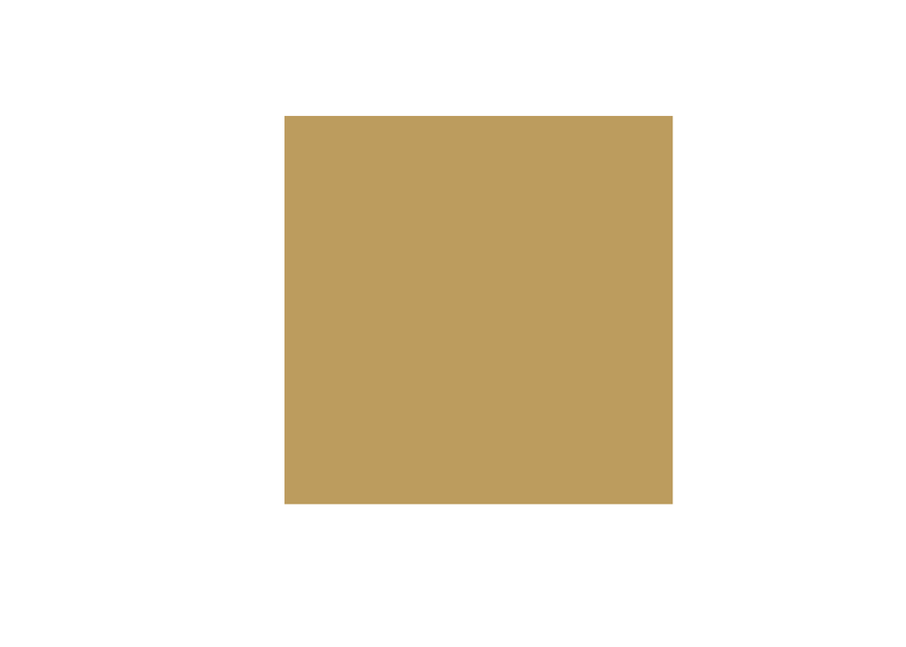

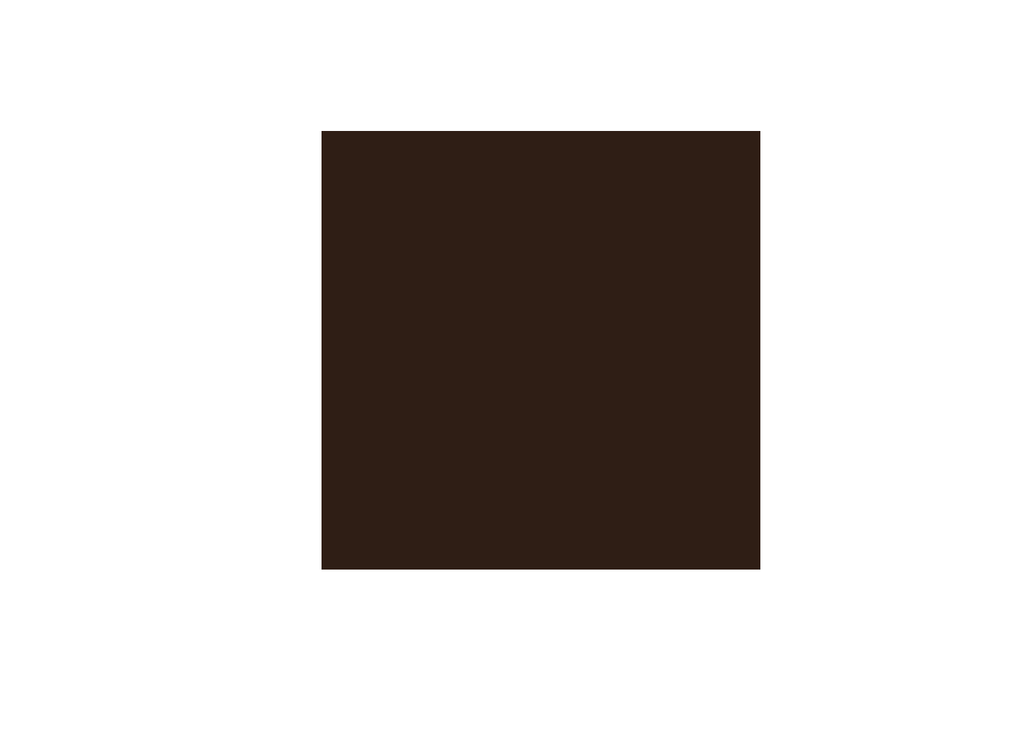

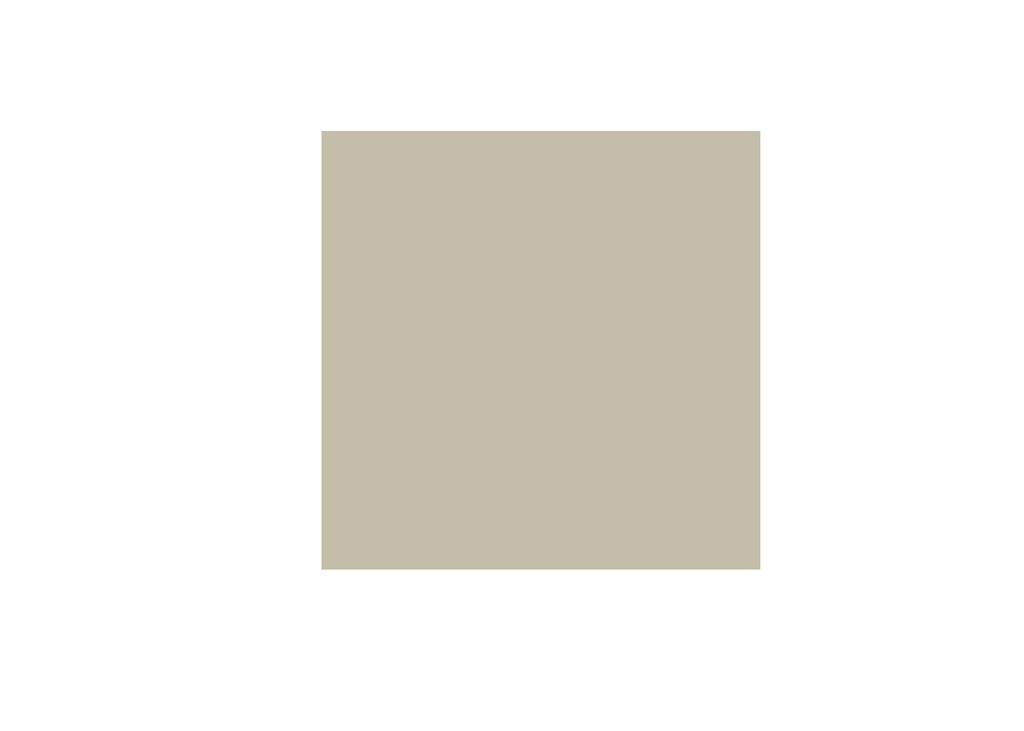

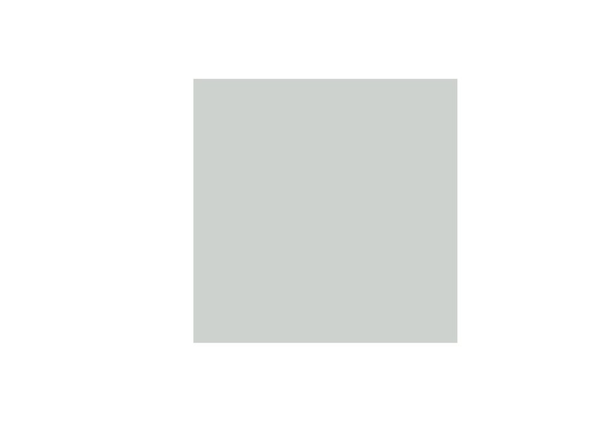

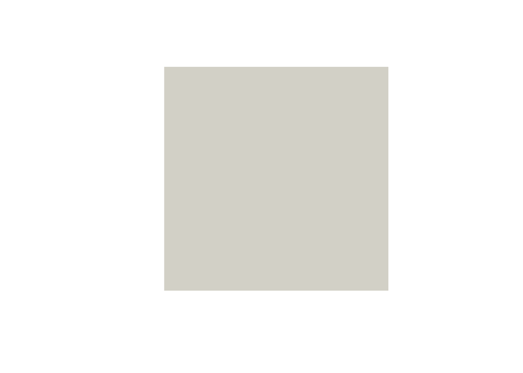

Three are notably darker, and looking at images correspond to visibly pigmented areas

Other 3 are different shades of white and tan, shades of unpigmented wings

## Q5: how are individuals spatially distributed?

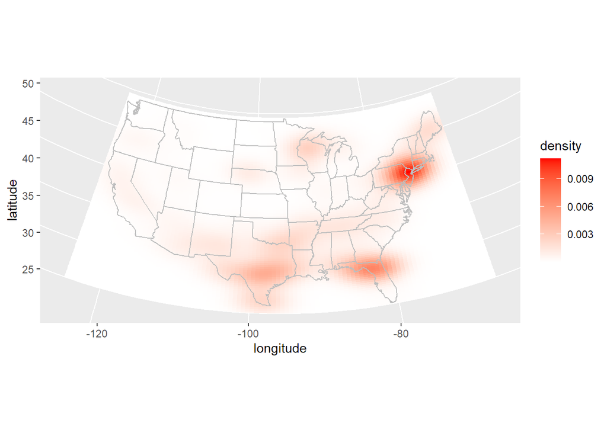

Somewhat biased towards populated east coast regions, but not too bad at all

## Q6: What do PCAs of the responses look like? How is the variation structured?

```
## Importance of components:
##                           PC1    PC2    PC3
## Standard deviation     1.0905 0.9938 0.9074
## Proportion of Variance 0.3964 0.3292 0.2744
## Cumulative Proportion  0.3964 0.7256 1.0000
## [1] "Rotation:"
##              PC1          PC2        PC3
## black  0.5136161 -0.698664039  0.4980633
## brown  0.6950237 -0.001609717 -0.7189850
## yellow 0.5031307  0.715448090  0.4847613
```

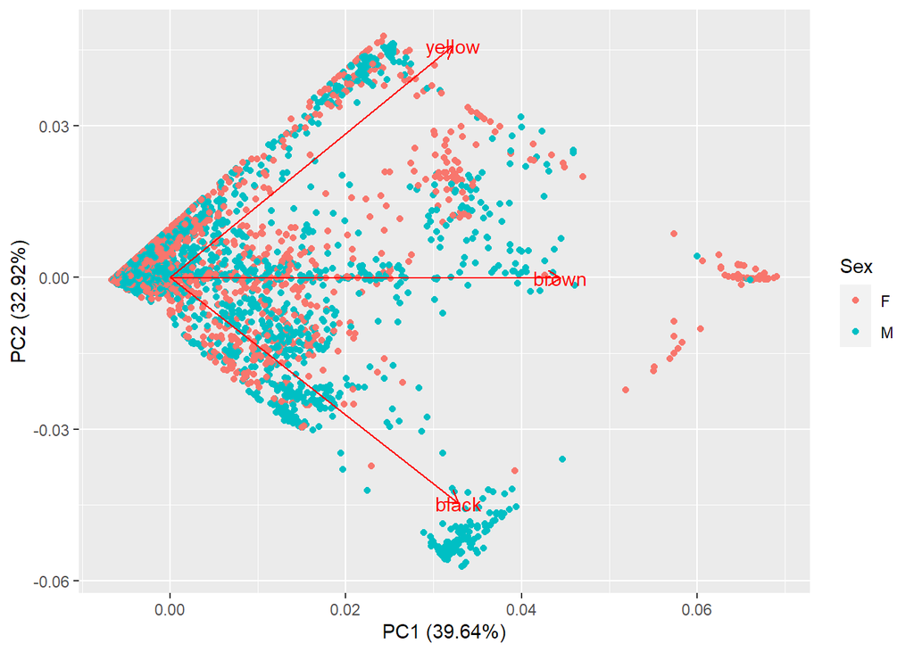

[output not shown]

[output cut: 22788 more lines]

```
## Importance of components:
##                           PC1    PC2    PC3    PC4
## Standard deviation     1.3489 1.2013 0.7393 0.4368
## Proportion of Variance 0.4549 0.3608 0.1366 0.0477
## Cumulative Proportion  0.4549 0.8157 0.9523 1.0000
## [1] "Rotation:"
##                     PC1        PC2         PC3         PC4
## all_fore_pc1  0.6656698 -0.2571902  0.11450940 -0.69110387
## all_fore_pc2 -0.2236511 -0.6658686  0.69625540  0.14774174
## all_hind_pc1  0.6992067 -0.1010125 -0.02211182  0.70740192
## all_hind_pc2 -0.1340667 -0.6930142 -0.70825637  0.01141698
```

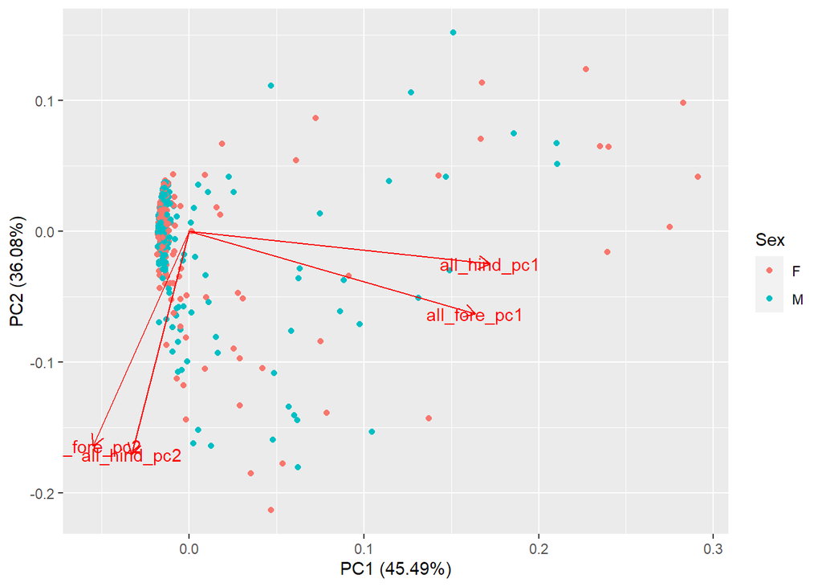

[output not shown]

[output cut: 1430 more lines]

```
## Importance of components:
##                           PC1    PC2    PC3    PC4     PC5     PC6     PC7
## Standard deviation     1.4013 1.3296 1.0337 0.9440 0.77923 0.71899 0.42972
## Proportion of Variance 0.2805 0.2526 0.1527 0.1273 0.08674 0.07385 0.02638
## Cumulative Proportion  0.2805 0.5331 0.6857 0.8130 0.89977 0.97362 1.00000
## [1] "Rotation:"
##                    PC1         PC2         PC3          PC4         PC5
## black        0.3397661  0.04877395 -0.63443133  0.416023311 -0.54100408
## brown        0.3174231  0.30723989 -0.54097053 -0.213820134  0.67219035
## yellow       0.3150913  0.31182487  0.09655817 -0.720182998 -0.47994150
## all_fore_pc1 0.5957883 -0.28727301  0.23166322  0.009775341  0.07743487
## all_fore_pc2 0.1606456  0.56365205  0.29069896  0.121547633  0.06632888
## all_hind_pc1 0.5150199 -0.43359445  0.20478164  0.060513954  0.12054944
## all_hind_pc2 0.1962212  0.46664380  0.33972791  0.493974374  0.01424859
##                      PC6          PC7
## black         0.11602194  0.021332761
## brown        -0.11938175  0.019651197
## yellow       -0.19632686  0.081287194
## all_fore_pc1  0.09794648 -0.702251662
## all_fore_pc2  0.73485747  0.113113346
## all_hind_pc1  0.01072748  0.697499550
## all_hind_pc2 -0.61969233  0.009668893
```

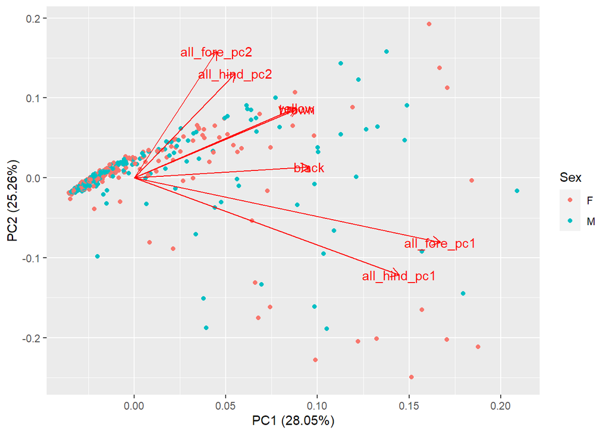

[output not shown]

[output cut: 1919 more lines]

Each axis of a PCA of wing PCs has the PC1s together and the PC2s together

PCA of all doesn’t account for as much variation and has the same relationships but with yellow and brown together